# Lección 03 — El grafo Roy (método de los potenciales)

Actividades en los nodos, cálculo hacia delante y hacia atrás, esperas y solapes

## Qué se aprende

A representar el proyecto con el **grafo Roy** (actividades en los nodos, prelaciones en los arcos), a calcular sobre él las fechas más tempranas y más tardías actividad a actividad, a compararlo con el PERT y a modelar relaciones que no son «fin-comienzo» (esperas y solapes).

## Conceptos

**Representación AoN (*activity on node*).** Cada actividad es un nodo, rectangular, en el que se anotan sus fechas; cada prelación inmediata $P \to A$ es un arco. Se añaden dos nodos auxiliares, *inicio* y *fin*, de duración cero, conectados a las actividades iniciales y finales. No hay ficticias: una prelación es un arco y nada más.

**Equivalencia con el PERT.** Los dos grafos describen el mismo orden parcial y dan el mismo calendario. El PERT tiene menos nodos y necesita ficticias; el Roy tiene tantos nodos como actividades y ningún arco artificial. En el Roy las fechas se escriben *en la actividad*; en el PERT, en los sucesos.

**Fechas de una actividad.** Con $d_A$ la duración:

- Inicio más temprano: $ES_A = \max_{P \in \text{pred}(A)} EF_P$ (0 si es inicial).
- Fin más temprano: $EF_A = ES_A + d_A$.
- Duración del proyecto: $T = \max_{A \text{ final}} EF_A$.
- Fin más tardío: $LF_A = \min_{S \in \text{suc}(A)} LS_S$ ($T$ si es final).
- Inicio más tardío: $LS_A = LF_A - d_A$.
- Holgura total: $H_A = LS_A - ES_A$ (lección 05).

**Esperas y solapes.** El Roy admite arcos con valor: un arco $P \to A$ de valor $\ell$ significa $ES_A \ge ES_P + \ell$. Con $\ell = d_P$ es la prelación ordinaria; con $\ell > d_P$ hay una **espera** (secado, curado) y con $\ell < d_P$ un **solape** (A puede empezar cuando P lleva $\ell$ unidades). De ahí el nombre «método de los potenciales»: las fechas son los potenciales que satisfacen todas las desigualdades de los arcos. Con prelaciones ordinarias, una espera se modela también añadiendo una actividad «espera» de duración $\ell - d_P$ entre P y A, y un solape dividiendo P en dos tramos.

## Algoritmo

**Paso hacia delante** (en orden topológico): $ES$ de las iniciales es 0; para cada actividad, $ES = \max$ de los $EF$ de sus predecesoras y $EF = ES + d$. Al terminar, $T$ es el mayor $EF$.

**Paso hacia atrás** (orden topológico inverso): $LF$ de las finales es $T$; para cada actividad, $LF = \min$ de los $LS$ de sus sucesoras y $LS = LF - d$.

El orden topológico es imprescindible: no se puede calcular $ES_A$ hasta tener el $EF$ de todas sus predecesoras.

## Ejemplo guía

| Act. | d | pred. | ES = máx EF pred. | EF | suc. | LF = mín LS suc. | LS | H |
| --- | --- | --- | --- | --- | --- | --- | --- | --- |
| A | 3 | — | 0 | 3 | C, D | mín(3, 6) = 3 | 0 | 0 |
| B | 2 | — | 0 | 2 | D, E | mín(6, 6) = 6 | 4 | 4 |
| C | 4 | A | 3 | 7 | F | 7 | 3 | 0 |
| D | 1 | A, B | máx(3, 2) = 3 | 4 | F | 7 | 6 | 3 |
| E | 2 | B | 2 | 4 | G | 8 | 6 | 4 |
| F | 3 | C, D | máx(7, 4) = 7 | 10 | — | 10 | 7 | 0 |
| G | 2 | E | 4 | 6 | — | 10 | 8 | 4 |

$T = 10$; críticas (holgura 0): A, C, F. Son exactamente los mismos números que da el PERT con los tiempos de los nodos (lección 04): $ES_A$ es el tiempo temprano del nodo del que sale A y $LF_A$ el tiempo tardío del nodo al que llega.

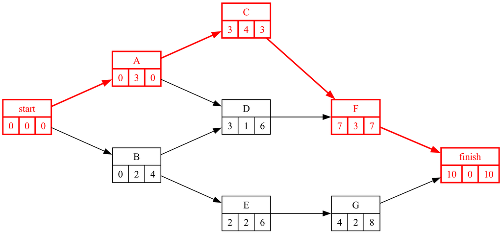

Grafo Roy del proyecto guía: en cada nodo, inicio más temprano, duración e inicio más tardío; en rojo el camino crítico

**Predecesora dominante.** En D, la predecesora que fija su inicio es A ($EF_A = 3 > EF_B = 2$): un retraso de B de hasta 1 unidad no mueve a D. Saber qué predecesora domina en cada máximo es lo que permite predecir, sin recalcular, qué retrasos importan.

## Con pmULE

```python
proyecto.roy(durations=datos['duration'])   # dibujo con fechas y camino crítico
proyecto.calendar(datos['duration'])        # ES, EF, LS, LF y las tres holguras
proyecto.pert(durations=datos['duration'])  # el PERT equivalente, con los mismos tiempos
```

## Preguntas de comprobación

- ¿Puede una actividad tener $LS < ES$? Sólo si se impone un plazo menor que $T$ (holguras negativas, lección 04).
- Si B se retrasa 1 unidad, ¿cambia algo? D sigue empezando en 3 (A domina) y E empieza en 3 en vez de 2, pero tiene holgura 4: nada cambia en el plazo.
- ¿Cómo se ve en el Roy una espera de 2 unidades entre C y F? Un arco C → F de valor $d_C + 2 = 6$, o una actividad «espera» de duración 2 entre ambas.

## Qué practica cada variante

*roy-vs-pert*: dibujar los dos grafos, contar nodos y arcos, calendario y camino crítico. *esperas-y-solapes*: modelar una espera y un solape con actividades auxiliares y ver su efecto. *predecesora-dominante*: calcular a mano hacia delante y atrás anotando qué predecesora fija cada máximo, y predecir el efecto de retrasos. *desde-sucesoras*: el cuadro viene como sucesoras; invertirlo y dibujar.